# MATH 331- Test 1

Before you begin the test, please use $R$ to create the lab report template **MATH331Test1_Your_First_LAST_NAME.Rmd**. This template makes it very simple to include code and output in your write up from within RStudio as well as ensuring reproducibility of your results. **NOTE:** please read the **SUBMISSION** and and **Academic Integrity** sections carefully. Late tests will not be accepted.

## Academic Integrity

All students are responsible for maintaining the highest standards of honesty and integrity in every phase of their academic careers. Any violation will be punished as severely as possible. Students who violate the honor codes will be reported and will receive an F.

1. An engineer is creating a project scheduling program and recognizes that the tasks making up the project are not always completed on time. However, the completion proportion tends to be fairly high. To reflect this condition, he uses the pdf $f(x|\theta)=\theta x^{\theta-1},\quad 0\leq x\leq 1,\quad\theta>0$. where $x$ is the proportion of the task completed. Suppose that in his previous project, the proportions of tasks completed were $0.77, 0.82, 0.92, 0.94$, and $0.98$. Use the method of moment to estimate $\theta$ (Please show your calculation steps in order to get full credits)
2. How much interest certificates of deposit (CDs) pay varies by financial institution and also by length of the investment. A five-year CD ties up an investor’s money, so it usually pays a higher rate of interest. However, higher rates might cause more variability. The table lists the five-year CD rate offerings from $n = 10$ banks in the northeast United States. Find a $89\%$ confidence interval for the average of 5-year assuming that the data is obtained from a normal population.

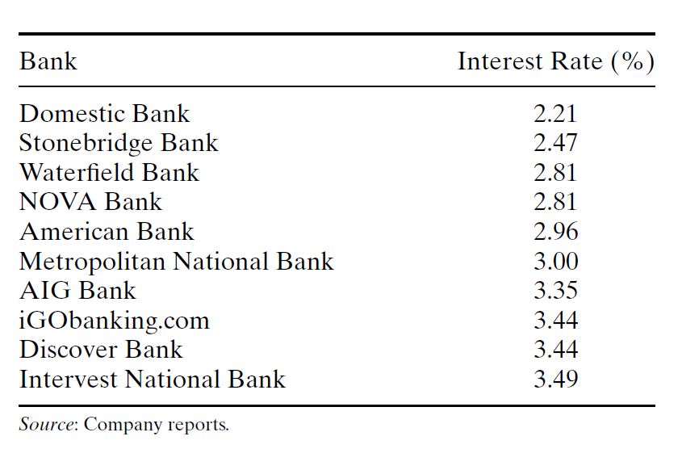

3. Assume that $X_1=100, X_2=98, X_3=105, X_4=90, X_5=100$ is an iid dataset obtained from the distribution whose the probability density function is given below
   $$f(x|\mu,\sigma)=\frac{1}{x\sigma\sqrt{2\pi}}\exp\left(-\frac{(\ln(x)-\mu)^2}{2\sigma^2}
   \right)$$
   a)Find the maximum likelihood to find estimates for $\mu$ and $\sigma$. b)Use the package “maxLik” to check your work.

## Submission

When you are finished, export **both** the Rmd and the HTML files you created. Please make sure you can see the HTML file. **Change** the names of the two files to **MATH331Test1_Your_First_LAST_NAME.Rmd** and **MATH331Test1_Your_First_LAST_NAME.HTML** . Now use the website **https://html2pdf.com/** to convert your **MATH331Test1_Your_First_LAST_NAME.HTML** to **MATH331Test1_Your_First_LAST_NAME.pdf**. Please upload (ONLY) the **MATH331Test1_Your_First_LAST_NAME.pdf** file Brightspace before the deadline.